# Simulando o problema de Monty Hall

Samuel Vianna Quintanilha

# Introdução

O problema de Monty Hall ( ou paradoxo de Monty Hall) surgiu baseado em um programa de tv dos Estados Unidos chamado *Let’s make a Deal*, em que o participante precisava escolher entre 3 portas, sendo que atrás de uma delas estava um Carro, enquanto nas outras estavam Cabras. Caso o participante acertasse em qual porta estivesse o carro, ele era todo seu.

Bem simples, não? Se existem 3 portas e 1 delas tem o carro então a chance do participante chutas e acertar é de $\frac{1}{3}$. Porém, o problema todo surge um pouco depois.

Após o participante escolher uma das portas, o apresentador abre uma das outras 2 portas restantes e revela uma cabra. Com essa informação, ele pergunta se o participante deseja trocar de porta. Com isso, surge a grande dúvida: **em termos de probabilidade, é vantajoso que o participante troque de porta?**

À primeira vista a resposta parece óbvia, pois se temos 2 portas, a chance de cada uma conter o prêmio é de 50%, então tanto faz trocar de porta ou não, certo?

**Errado!!!** Na verdade, espera-se que ele ganhe $\frac{2}{3}$ das vezes em que optar trocar de porta, enquanto sua chance de sucesso caso fique com a mesma porta inicial é de $\frac{1}{3}$.

Mas como isso é possível? Qual é a lógica por trás disso? É o que será explicado a seguir.

# A explicação por trás do problema

O segredo para entender esse problema consiste em saber que a escolha do participante é aleatória, enquanto a do apresentador não.

No início do jogo, o participante tem 3 opções, então, após escolehr uma das portas, pode-se pensar em 2 cenários:

1. O participante acertou em qual porta está o prêmio
2. O participante errou em qual porta está o prêmio

Caso o participante tenha de fato acertado de primeira aonde está o carro, é indiferente qual porta o apresentador irá abrir, dado que ambas possuem cabras atrás delas. Porém, caso o participante tenha errado em sua primeira escolha, então o apresentador (que sabe aonde o carro está) obviamente terá de “manipular” sua ação e abrir a porta em que sabe que o carro não está.

Com isso, a visão sobre a probabilidade desses cenários começa a se tornar um pouco mais clara.

## Analisando os cenários mais a fundo

Como o participante não sabe em qual porta está o prêmio, então, teoricamente, sua chance de acertar de primeira é de $\frac{1}{3}$. Ou seja, cerca de 33.33% das vezes será indiferente a escolha do apresentador de qual porta abrir, já que o prêmio já está atrás da porta escolhida pelo participante.

Por outro lado, em $\frac{2}{3}$ das vezes o participante escolherá a porta errada, então, o apresentador terá que escolher mostrar a porta com a cabra, restando como outra porta aquela que possui o prêmio.

Ou seja, ao ser oferecida a troca, cerca de 2 a cada 3 vezes o prêmio estará atrás da porta não escolhida e por isso é vantajoso realizar a troca.

## Uma outra perspectiva

Para melhor entender o conceito aplicado acima, pense no mesmo jogo com a seguinte alteração: agora há 100 portas para serem escolhidas e somente 1 contém o prêmio.

Seguindo as regras do jogo original, após o participante escolher a porta, o apresentador abriria 98 portas com cabras, e então oferecia a troca.

Após aplicar o mesmo conceito, é fácil entender que ao trocar de porta suas chances de ganhar aumentarm de $\frac{1}{100}$ para $\frac{99}{100}$.

# Simulação

Para exemplificar o problema, serão realizadas algumas simulações para verificar se esse realmente é o resultado esperado

## Explicação do algoritmo

A ideia aplicada é a seguinte: Para exemplificar as 3 portas, é utilizado um vetor com os números de 1 a 3. Então, é escolhido aleatóriamente um dos números para ser a escolha do participante e outro para ser a porta com o prêmio.

O número da porta escolhida e do prêmio sejam o mesmo, então é retirado do vetor o número selecionado e um outro aleatório.

Caso a porta escolhida não seja a do prêmio, então é retirado do vetor o número selecionado e o outro que não contém o prêmio.

Para exemplificar a troca de portas, caso o número da porta com o prêmio seja igual ao número restante no vetor, então significa que o participante ganhou o prêmio ao trocar de porta.

**Obs**: O caso em que o participante ganha é representado por 1, e quando perde é representado por 0.

## O algoritmo

Dado a explicação acima, pode ser definida a seguinte função:

```r
jogo <- function (){
  portas <- c(1,2,3) # possíveis portas

  chute  <- sample(portas, 1) # porta escolhida pelo jogador
  premio <- sample(portas, 1) # porta com o prêmio

  if(premio == chute){ # condição para quando acerta no primeiro palpite
    portas <- portas[-which(portas == chute)]

    porta_aberta <- sample(portas,1)

    portas <- portas[-which(portas == porta_aberta)]
  } else { #condição para quando quando erra no primeiro palpite
    portas <- premio
  }

  resultado <- premio==portas # verificação se ganhou ao trocar de porta

  dados <- c(chute, premio, resultado) #elementos a serem retornados pela função

  return(dados)

}
```

Realizando a simulação 100 vezes, obtém-se o seguinte resultado:

```r
set.seed(555) # definindo semente
n <- 100 #numéro de simulações

replicate(n, jogo()) %>% # simulando 10 jogos
  as.data.frame() %>% t()  -> jogos # transformando em um data frame e atribuindo ao ojbeto jogos

row.names(jogos) <- c(1:n) # mudando nome das linhas
colnames(jogos) <- c('chute', 'premio', 'resultado') # mudando nome das colunas

head(jogos, n = 10) # pritando os 10 resultados
```

```
##    chute premio resultado
## 1      2      1         1
## 2      1      1         0
## 3      1      2         1
## 4      2      1         1
## 5      2      1         1
## 6      1      1         0
## 7      1      1         0
## 8      3      2         1
## 9      2      3         1
## 10     3      2         1
```

```r
mean(jogos[,3]) # média de vezes que ganhou ao trocar de porta
```

```
## [1] 0.69
```

O resultado obtido empiricamente foi próximo ao esperado, porém, não se pode concluir algo simplesmente olhando uma estimativa de 100 jogos. Dado que existe uma probabilidade de ao acaso o participante perder ou ganhar em todos os 100 jogos. Com isso, a fim de verificar de fato o comportamento desse fenômeno, serão simuladas 1000 amostras, em que cada uma representa a média de vezes em que o participante ganhou após trocar de porta em 100 jogos.

## Realizando a simulação

```r
# modificando a função para retornar somente o resultado
jogo_v2 <- function (){
  portas <- c(1,2,3) # possíveis portas

  chute  <- sample(portas, 1) # porta escolhida pelo jogador
  premio <- sample(portas, 1) # porta com o prêmio

  if(premio == chute){ # condição para quando acerta no primeiro palpite
    portas <- portas[-which(portas == chute)]

    porta_aberta <- sample(portas,1)

    portas <- portas[-which(portas == porta_aberta)]
  } else { #condição para quando quando erra no primeiro palpite
    portas <- premio
  }

  resultado <- premio==portas # verificação se ganhou ao trocar de porta

  return(resultado)

}

# simulando os jogos
n <- 100
m <- 1000

set.seed(555) # definindo semente

resultados <- replicate(m, mean(replicate(n, jogo_v2()))) # simulando

resultados %>% as.data.frame() -> resultados # transformando resultados em data frame

colnames(resultados) <- c('media') # mudando nome das colunas
```

## Análise estatística

Após realizar as simulações, o histograma a seguir representa o comportamento do resultado da média de vitórias de cada simulação de 100 jogos.

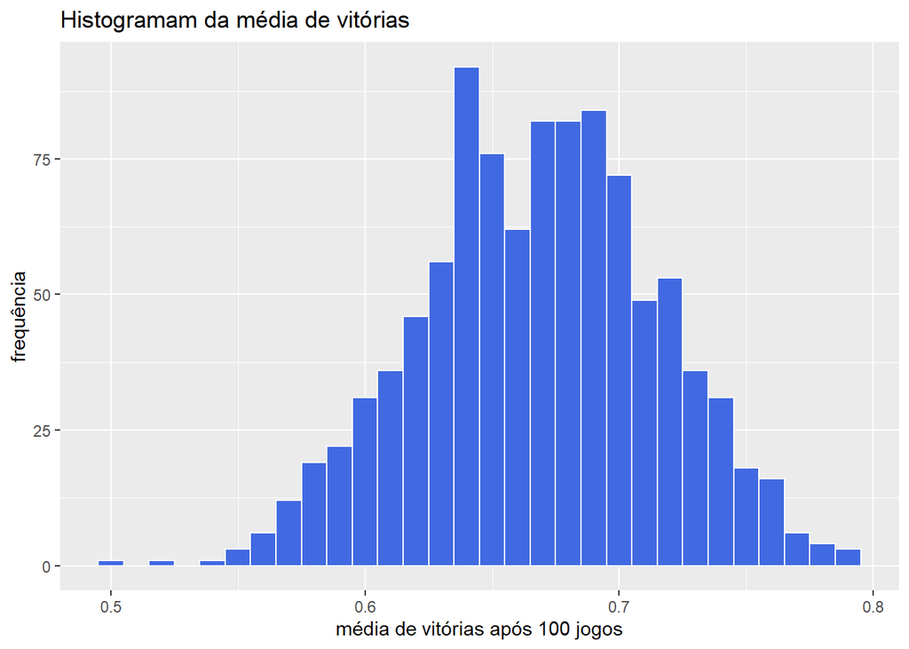

```r
 resultados %>%
  ggplot(aes(x=media)) + geom_histogram(col='white', fill='royalblue', binwidth = 0.01) +
  labs(x='média de vitórias após 100 jogos', y='frequência') +
  ggtitle('Histogramam da média de vitórias')
```

Considerando normalidade dos dados a partir do teorema do limite central e aplicando o teste T para verificar se a média é significativamente diferente de $\frac{2}{3}$, é obtido o seguinte resultado:

```r
t.test(resultados$media, mu = 2/3)
```

```
##
##  One Sample t-test
##
## data:  resultados$media
## t = 0.87915, df = 999, p-value = 0.3795
## alternative hypothesis: true mean is not equal to 0.6666667
## 95 percent confidence interval:
##  0.6650608 0.6708792
## sample estimates:
## mean of x
##   0.66797
```

Com os resultados obtidos, não se rejeita a hipótese nula à um nível de significância de 5%, ou seja, não há indícios estatísticos que comprovam que a média de ganhos ao trocar a porta seja diferente de $\frac{2}{3}$.

Realizando o teste não paramétrico de Wilcoxon para 1 amostra, obtém-se o seguinte resultado:

```r
wilcox.test(resultados$media, mu = 2/3)
```

```
##
##  Wilcoxon signed rank test with continuity correction
##
## data:  resultados$media
## V = 254924, p-value = 0.6088
## alternative hypothesis: true location is not equal to 0.6666667
```

Novamente, à um nível de significância de 5%, não se rejeita a hipótese nula.

# Conclusão

Com isso, foi possível observar empiricamente o pensamento por trás do problema de Monty Hall, em que realmente há vantagem ao trocar a porta, dado as condições do problema.